# 第9回 散布図・共分散・相関係数

経済データ入門

第9回

散布図・共分散・相関係数

2 つの列が一緒に動くかを、点の並びで見て、1 つの数で言う

経済データ入門

第9回 — Topic01

散布図

表では見えない関係を、点の並びで見る

## 前回の振り返り

前回のポイント 第8回「前半振り返り・中間レポート解説」

Q: 1都3県の 3 つの割合が、そろわなかったのはなぜか

- **割合**：部分 ÷ 全体。分母は 47 都道府県の合計
- **数え方**：人口は住む場所、県内総生産は働く場所で数える
- **主張の前に**：何を数えた統計かを書く

今日は 2 つの数の関係を見る。一方が多い人ほど、  
もう一方も多い（少ない）か

## この回の道のりと「5人」シート

1

散布図

演習 9-1

36 年の散布図

2

共分散

演習 9-2

36 年の共分散

3

相関係数

演習 9-3

分で数えた相関

4

相関と因果

演習 9-4

外れ値の前後

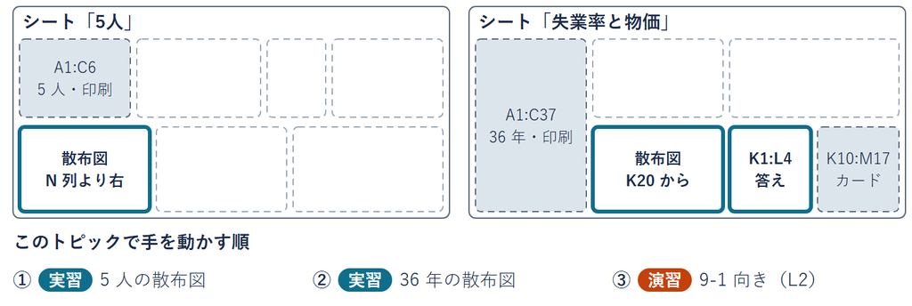

置き場は lec9-exercise.xlsx の 2 枚のシート

## 5 人のバイト日数と自習時間

バイトを多く入れる人ほど、自習の時間は短いのか  
5 人に、1 週間のバイトの日数と自習の時間を聞いた

| 名前 | バイト日数 x（日/週） | 自習時間 y（時間/週） |
| --- | --- | --- |
| A | 1 | 9 |
| B | 2 | 10 |
| C | 3 | 6 |
| D | 4 | 2 |
| E | 5 | 3 |

**サンプルデータ**：架空の 5 人（lec9-exercise.xlsx「5人」の A1:C6）

## たしかめ 表から読む向き

B は A よりバイトが多いのに、自習も長い  
この 5 人のデータから、全体として  
「バイトが多いほど自習が短い」と言えるか

**1 言える**

**2 B が逆なので言えない**

1 つ決めてから先へ。答えは、このトピックの中で出す

## 表の行と点の対応

[figure not shown]

横にバイト日数 x、縦に自習時間 y。A は（1, 9）の位置に打つ

## 散布図

用語

**散布図**：2 つの数の組を、1 行 1 つの点で打った図

**横の軸 x**：見る条件にあたる数（ここではバイト日数）

**縦の軸 y**：x の値ごとに、どうなるかを見たい数（自習時間）

- **今回は**：5 つの点が、左上から右下へ並ぶ
- **B の点**：A の点より少し上にある

たしかめの答えは 1 番  
B だけ逆向きでも、点に並べると全体の並びは右下がり

## 5 人の散布図の挿入

1. **選ぶ**：B1:C6 をドラッグ  
   名前の列 A は入れない
2. **挿入**：「挿入」タブ → 点が散ら  
   ばった絵のボタン  
   → いちばん左上の「散布図」
3. **見る**：右下がりの 5 点  
   枠をドラッグして N 列より右へ

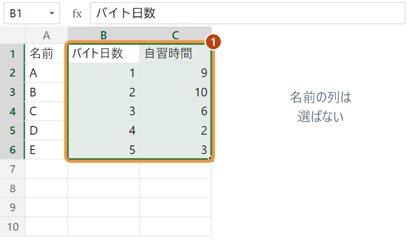

[figure not shown]

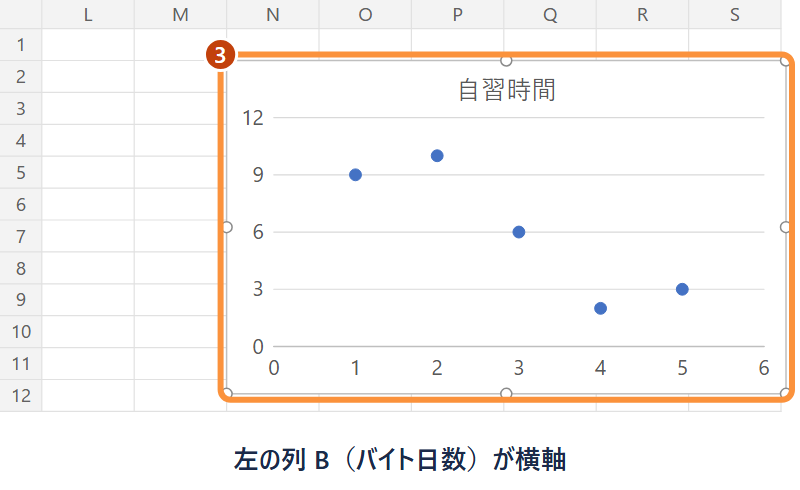

Mac も同じ「挿入」タブの散布図

✋ 動画を止めて ①〜③ を進め、5 点が出たら再生に戻る

## Q&A 散布図の作り方

Q1 点が 5 つでない。色の違う点や凡例が出た

名前の列 A まで選んでいる。グラフを消して  
**B1:C6 だけ**を選び、散布図を入れ直す

Q2 グラフの下にセルが隠れた

グラフの枠をドラッグして **N 列より右**へ動かす。列は動かさない

Q3 点が線でつながった

線のある形を選んでいる。一覧の**いちばん左上の「散布図」**を選ぶ

## 完全失業率と物価上昇率

仕事が見つかりにくい年は、物の値段はどう動いているのか  
日本の 36 年で、同じように散布図を作る（1 行は 1 つの年）

- **完全失業率**：働きたい人のうち、仕事がない人の割合（%）
- **物価上昇率**：1 年前と比べた値段の上がり方（%）  
  マイナスの年は、値段が下がった年
- **失業率の調整**：季節でくり返す動きを外した値（季節調整値）
- **物価の調整**：天候で振れる野菜や魚を外した値（季節調整値ではない）
- **36 年**：統計局の月ごとの数の年平均（2026 年は 1〜5 月）
- **横と縦**：失業率を横に置く。仕事が見つかりにくい年に、  
  値段がどうなるかを見たい

## 2 つの統計のデータカード

| 欄 | 労働力調査（完全失業率） | 消費者物価指数（物価上昇率） |
| --- | --- | --- |
| 統計名 | 長期時系列 表1a-1 完全失業率 男女計 | 全国 生鮮食品を除く総合 前年同月比 |
| 作成機関 | 総務省統計局 | 総務省統計局 |
| 調査 | 全員ではなく約 4 万世帯に聞く・毎月 | お店の値段の調査をまとめ直 した数・毎月 |
| 単位 | %・季節の動きを外した値 | %（1 年前の同じ月と比べる） |
| 落とし穴 | 探すのをあきらめた人は数えない | 先月とではなく 1 年前の 同じ月と比べる |
| 入手先 | e-Stat 表1a-1・2026-07-19 取得 | 統計局 長期時系列・2026-07-19 取得 |

## 36 年の表

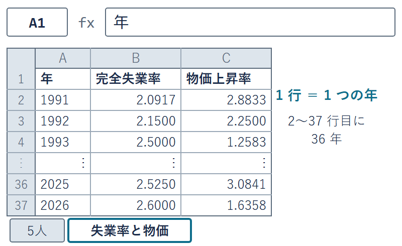

**実データ**：総務省統計局（2026-07-19 取得）。小数点以下 4 桁のまま使う  
36 行を上から読んでも、向きは追いにくい

## 36 年の点の雲

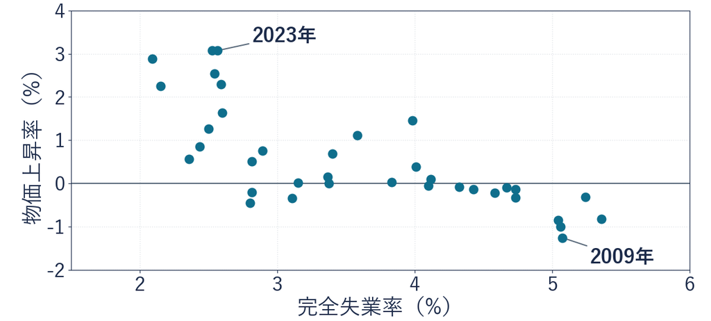

点にすると、36 年は全体として右下がりと分かる  
折れ線 2 本と違い、年の順を捨てて 2 つの数の組だけを点にする

## 36 年の散布図の挿入

1. **選ぶ**：B1 をクリック  
   Shift を押しながら C37 をクリック  
   近道：B1:C1 → `Ctrl + Shift + ↓`
2. **挿入**：点が散らばった絵のボタン  
   → いちばん左上の「散布図」
3. **見る**：全体として右下がりの 36 点  
   枠をドラッグして K20 から下へ

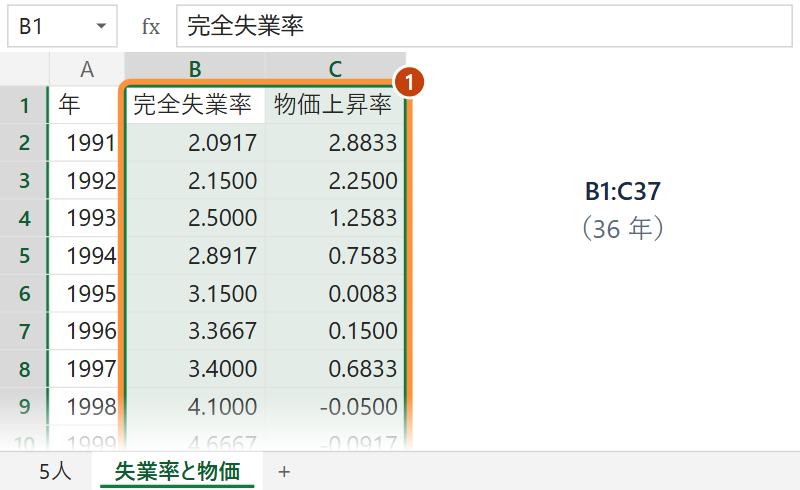

[figure not shown]

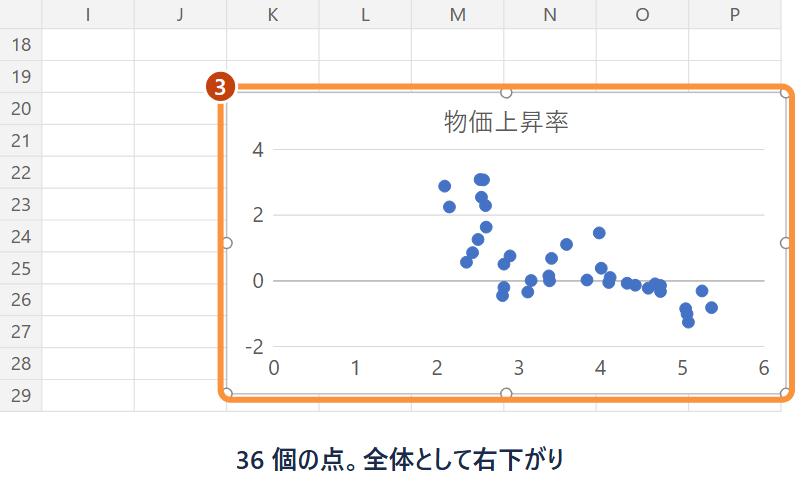

Mac の近道は `⌘ + Shift + ↓`

✋ 動画を止めて ①〜③ を進め、36 点が出たら再生に戻る

## 演習 9-1 36 年の散布図と向き

演習 9-1

36 年の散布図に題と軸ラベルを付け、向きを 1 文で書く

1. **題**：「物価上昇率」を 2 回クリック  
   文字を消して右の図の題を打つ
2. **軸ラベル**：グラフを選ぶ  
   「＋」→「軸ラベル」に印  
   文字を書き換える
3. **向き**：点の雲の向きを 1 文で  
   「失業率と物価」の L2 に書く

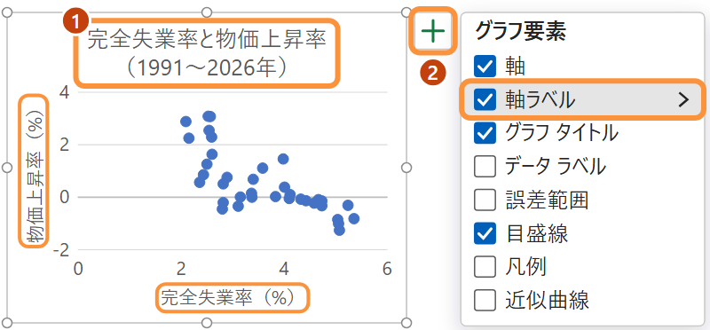

Mac では「グラフのデザイン」→「グラフ要素を追加」→ 軸ラベル  
**実データ**：シート「失業率と物価」の A1:C37（36 年）

## 散布図の読み方

**散布図：表では見えない関係が、点の並びで見える**

- **向き**：右上がりか、右下がりか
- **まとまり**：1 本の線に沿うか、雲のように広がるか
- **外れた点**：1 つだけ遠くにいる点がないか
- **軸の約束**：見る条件にあたる数を横に置く。原因という意味ではない

## 右上がり・右下がり・ばらばら

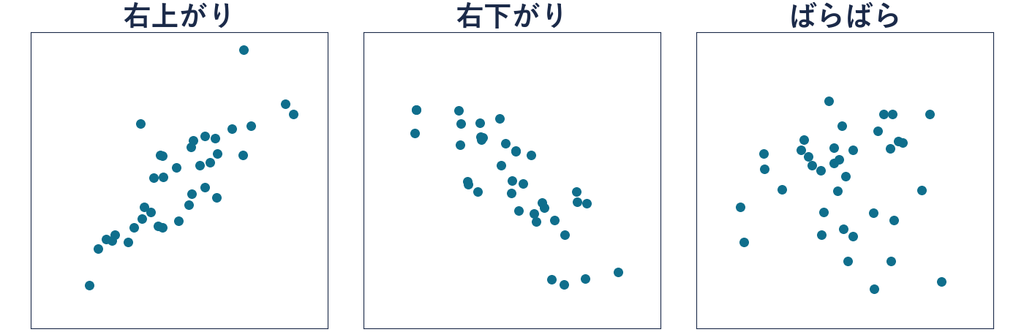

どの雲かは目で言える。どれくらい右下がりかは、まだ言葉だけ

## まとめ

- **散布図**：1 行を 1 つの点にして、横に x・縦に y をとった図
- **読み方**：向き・まとまり・外れた点。左の列が横軸
- **5 人**：右下がり。B だけ逆向きでも、全体の並びが先に目に入る
- **36 年**：全体として、完全失業率が高い年ほど、物価上昇率が低い

右下がりは目で言えた。では、どれくらい右下がりかを数で言えるか  
これを次のトピックで見る

経済データ入門

第9回 — Topic02

共分散

平均の十字で、ずれを掛け合わせる

## この回の道のりと「5人」シート

1

散布図

演習 9-1

36 年の散布図

2

共分散

演習 9-2

36 年の共分散

3

相関係数

演習 9-3

分で数えた相関

4

相関と因果

演習 9-4

外れ値の前後

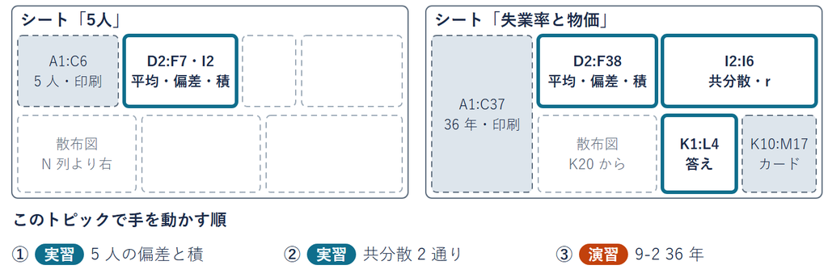

置き場：「5人」D2:F6・7 行目・I2 ／「失業率と物価」D2:F37・38 行目

## 偏差と分散

用語

**偏差**：値から平均を引いた数。平均からのずれ

**分散**：偏差の 2 乗の平均（人数 n で割る）

- **第 3 回**：1 つの列の散らばりを、1 つの数で言う道具だった
- **x**：1〜5 で平均 3 → 偏差 −2, −1, 0, 1, 2  
  分散 (4 + 1 + 0 + 1 + 4) ÷ 5 ＝ 2
- **y**：9, 10, 6, 2, 3 で平均 6 → 偏差 3, 4, 0, −4, −3  
  分散 (9 + 16 + 0 + 16 + 9) ÷ 5 ＝ 10

## 分散で言えない向き

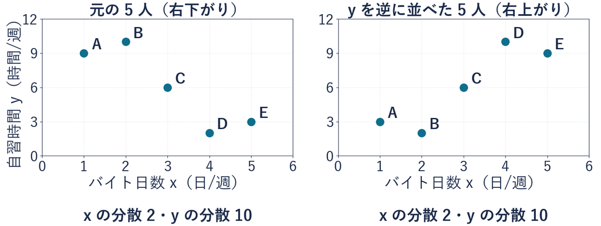

自習時間を逆さに並べる（A ＝ 3, B ＝ 2, …, E ＝ 9）と右上がり  
でも分散は 2 と 10 のまま。分散は 1 列ずつしか見ない

## 平均の十字と 4 つの区画

[figure not shown]

平均より多くバイトする人は、平均より自習が少ないか  
右下がりなら、点は左上と右下に集まる

## 区画と偏差の符号

| 区画 | x の偏差 | y の偏差 |
| --- | --- | --- |
| 右上 | ＋ | ＋ |
| 左上 | － | ＋ |
| 左下 | － | － |
| 右下 | ＋ | － |

欲しいのは、符号が同じなら＋、違えば－になる計算

足すと A（左上）：x の偏差 −2・y の偏差 3 → −2 ＋ 3 ＝ ＋1

足すと D（右下）：x の偏差 1・y の偏差 −4 → 1 ＋（−4）＝ −3

掛けると 右上 ＋・左上 －・左下 ＋・右下 －  
区画が 1 つの符号になる。右下がりの区画はマイナス

## たしかめ 偏差の積の合計

5 人それぞれで x の偏差 × y の偏差を出して、全部足す  
合計はプラス、マイナス、0 のどれになるか

**1 プラス**

**2 マイナス**

**3 0**

1 つ決めてから先へ。答えは、次のページで出す

## 5 人の偏差の積

偏差の組（x, y）：A（−2, 3）・B（−1, 4）・C（0, 0）・D（1, −4）・E（2, −3）

A（左上）

$(-2) \times 3$

$= -6$

マイナス × プラス

B（左上）

$(-1) \times 4$

$= -4$

左上の 2 人で −10

C（十字の交点）

$0 \times 0$

$= 0$

向きに効かない

D（右下）

$1 \times (-4)$

$= -4$

プラス × マイナス

E（右下）

$2 \times (-3)$

$= -6$

右下の 2 人で −10

合計

$-10 + 0 - 10$

$= -20$

答えは 2 番

**サンプルデータ**：5 人の表（「5人」の A1:C6）

## 共分散

**共分散：平均の十字で 4 つに分け、ずれの掛け算で向きを測る**

定義

$$\textbf{共分散} =(\textbf{x の偏差} \times \textbf{y の偏差}) \textbf{ の平均}$$

今回は

$(-20) \div 5$

$= -4$

1 人あたりにそろえる（人数 n で割る）

2 組なら

$(-40) \div 10$

$= -4$

同じ 5 人を 2 組並べても −4 のまま

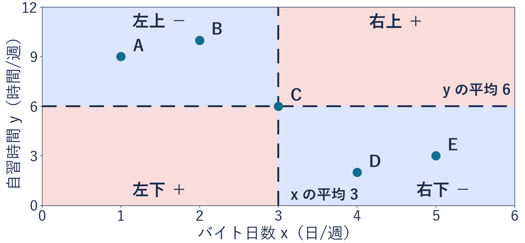

## 共分散の符号

- **マイナス**：右下がり。左上と右下の積（−）の合計のほうが大きい
- **プラス**：右上がり。右上と左下の積（＋）の合計のほうが大きい
- **決めるもの**：積をすべて足した合計の符号
- **大きさ**：単位しだいで変わる（単位は「日 × 時間」）  
  −4 は「1 日で 4 時間減る」ではない
- **分散**：（x の偏差 × x の偏差）の平均
- **共分散**：（x の偏差 × y の偏差）の平均

共分散 −4 はマイナス。右下がりを符号で言えた

## 割る数 n と n − 1

用語

**COVARIANCE.P**：偏差の積の合計を人数 n で割る

**COVARIANCE.S**：人数より 1 少ない n − 1 で割る

- **5 人なら**：n で割ると −4・n − 1 で割ると −5
- **S を使う場面**：5 人を「大学生全体」の一部とみて、  
  全体の関係を推し量るとき
- **n − 1 の理由**：手元の平均から測ったずれは少し小さく出る  
  割る数を 1 つ減らして補う
- **名前**：P は全体（population）、S は一部（sample）の頭文字
- **この授業**：第 3 回の分散と同じく n で割る

## 5 人の偏差と積の列

1. **平均**：B7 に `=AVERAGE(B2:B6)`  
   C7 へコピー → 3 と 6
2. **偏差**：D2 に `=B2-$B$7`、  
   E2 に `=C2-$C$7`  
   → D2:E2 を 6 行目までフィル
3. **積**：F2 に `=D2*E2`  
   F6 まで → −6, −4, 0, −4, −6

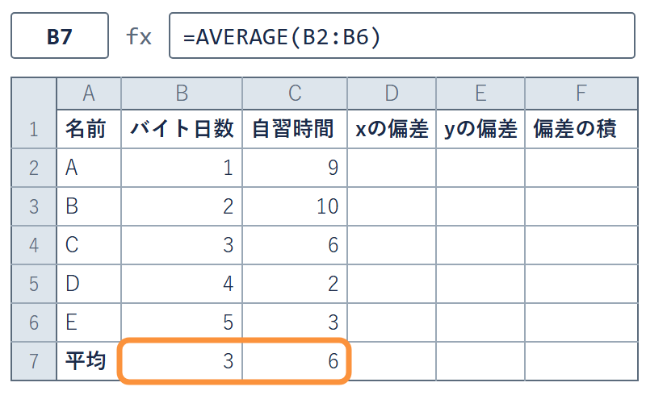

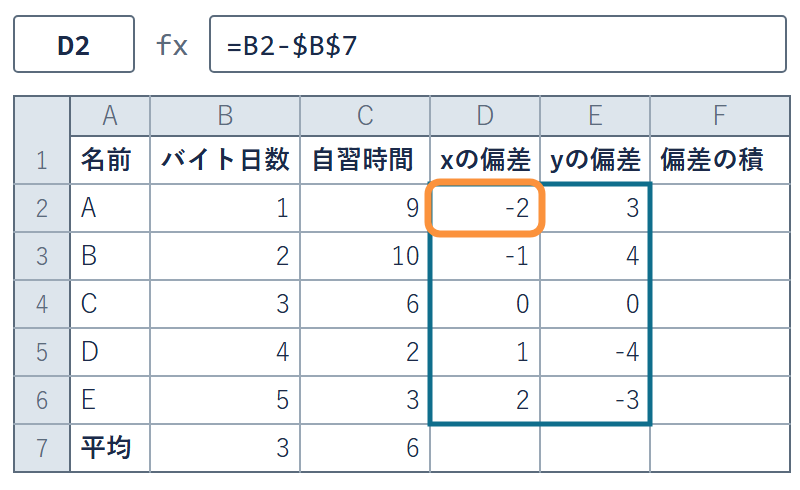

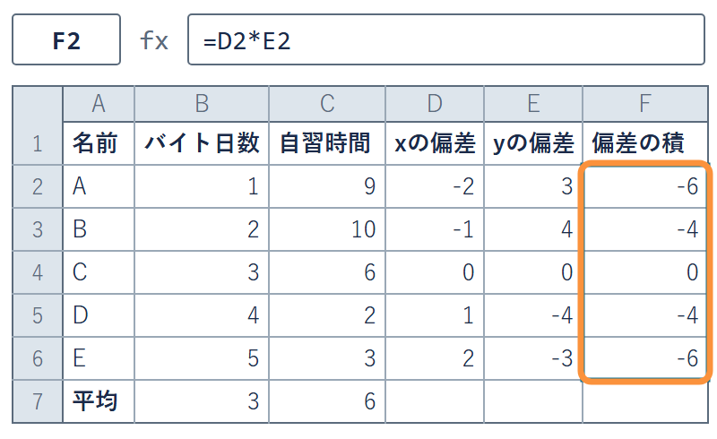

`$` は数式バーの中の「B7」の字を選んで F4（Mac では ⌘ + T）

✋ 動画を止めて ①〜③ を進め、F 列がそろったら再生に戻る

## 5 人の共分散の 2 通り

1. **表の列で**：F7 に  
   `=AVERAGE(F2:F6)` → −4
2. **関数で**：I2 に

   ```
   =COVARIANCE.P
   (B2:B6,C2:C6)
   ```

   → −4
3. **見る**：F7 と I2 が同じ −4  
   別の道で同じ答え

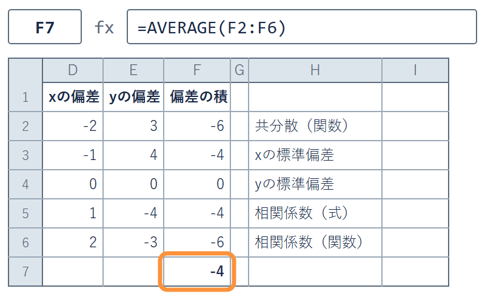

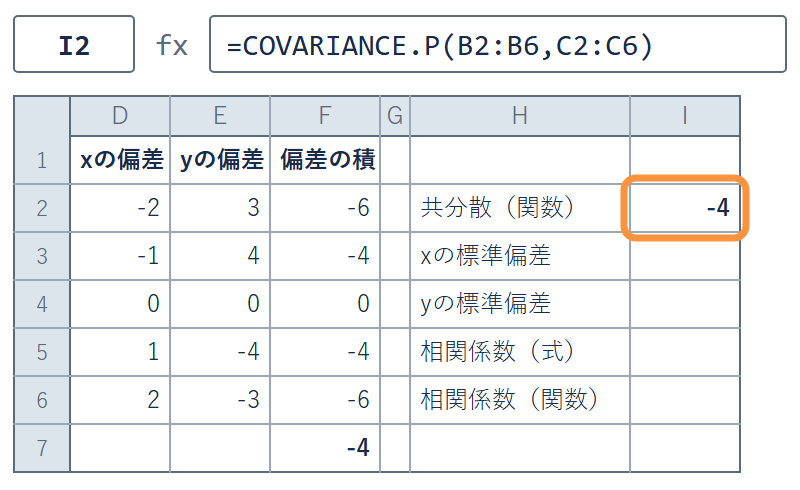

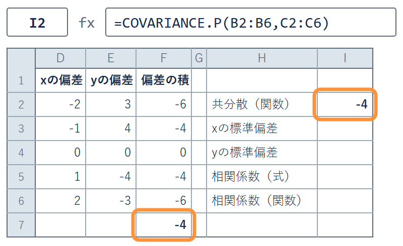

✋ 動画を止めて ①〜③ を進め、どちらも −4 なら再生に戻る

## Q&A 偏差と共分散

Q1 D 列が 3 行目から崩れた

どの行も同じ平均 B7 を引くので、`$` で固定する（絶対参照）  
D3 が **`=B3-$B$7`** になっているかを見る

Q2 関数の答えが −5 になった

COVARIANCE.S を選んでいる。**COVARIANCE.P**（n で割る）に直す

Q3 C の積が 0 なのは間違いか

C は十字の交わる点にいる。**向きに効かない点**なので 0 で正しい

## 36 年の平均の十字

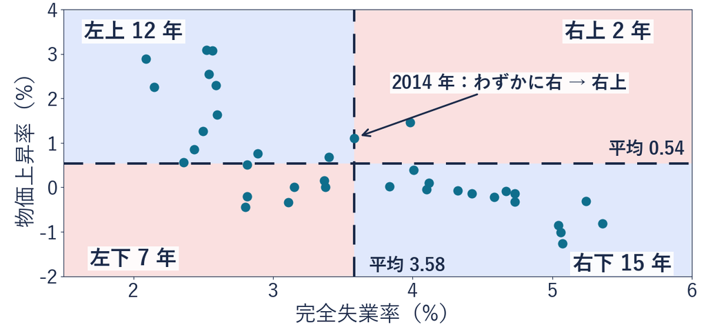

右下がりの区画に 27 年（左上 12 ＋ 右下 15）。共分散は −0.852  
**実データ**：総務省統計局 労働力調査・消費者物価指数

## 演習 9-2 36 年の偏差の積

演習 9-2

36 年の共分散を、表の列と関数の 2 通りで出す

1. **平均**：B38・C38 に 2〜37 行目の平均（3.58 と 0.54）
2. **列**：D2 に `=B2-$B$38`、E2 に `=C2-$C$38`、F2 に `=D2*E2`  
   → D2:F2 を 37 行目までフィル
3. **2 通り**：F38 に F 列の平均、I2 に `=COVARIANCE.P(B2:B37,C2:C37)`
4. **答え**：L3 に共分散を小数第 3 位まで、L4 に一致したかを「はい」か「いいえ」で

**実データ**：シート「失業率と物価」の A1:C37（36 年）

## まとめ

- **平均の十字**：散布図を 4 つの区画に分ける
- **偏差の積**：左上と右下はマイナス、右上と左下はプラス
- **共分散**：偏差の積の平均。5 人は −20 ÷ 5 ＝ −4
- **36 年**：共分散 −0.852 もマイナスで右下がり

符号で向きは言えた。では −4 と −0.852 のどちらが強い右下がりか  
これを次のトピックで見る

経済データ入門

第9回 — Topic03

相関係数

単位を消して、−1 から 1 にそろえる

## この回の道のりと「5人」シート

1

散布図

演習 9-1

36 年の散布図

2

共分散

演習 9-2

36 年の共分散

3

相関係数

演習 9-3

分で数えた相関

4

相関と因果

演習 9-4

外れ値の前後

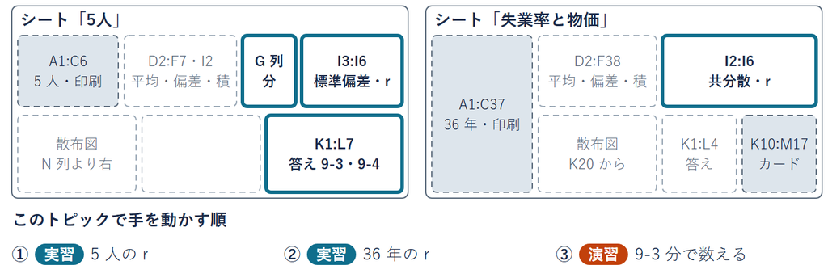

置き場は「5人」の I3:I6・G 列・I9:I10 ／「失業率と物価」の I3:I6

## 2 つの共分散

**5 人**  
共分散 −4

**36 年**  
共分散 −0.852

どちらもマイナスで、右下がり  
では、どちらのほうが強い右下がりと言えるか

## 分で数えた自習時間

[figure not shown]

点の並びは同じなのに、共分散は −4 が −240（60 倍）

## 共分散と単位

- **分で数える**：自習時間も偏差も、どれも 60 倍になる
- **共分散**：積も 60 倍なので、−4 が −240 になる
- **単位**：共分散の単位は「日 × 時間」。ふだん使わない単位
- **困ること**：同じ 5 人、同じ関係なのに、数え方で大きさが変わる

大きさが単位に引きずられるなら、単位を消せばよい

## 標準偏差

用語

**標準偏差**：その列の、平均からのふつうのずれの大きさ

- **第 3 回**：分散の平方根。単位は元の列と同じ
- **今回は**：分散 2 の平方根で x は √2 ≒ 1.41 日、  
  分散 10 から y は √10 ≒ 3.16 時間
- **分で数えると**：y は 60 倍の 189.7 分
- **Excel では**：`STDEV.P(範囲)`。n で割る標準偏差

## ふつうのずれの何個分

[figure not shown]

時間でも分でも、A のずれは同じ 0.95 個分

## 何個分どうしの積

| 名前 | x の偏差 ÷ 1.414 | y の偏差 ÷ 3.162 | 掛けると |
| --- | --- | --- | --- |
| A | −1.414 | 0.949 | −1.342 |
| B | −0.707 | 1.265 | −0.894 |
| C | 0 | 0 | 0 |
| D | 0.707 | −1.265 | −0.894 |
| E | 1.414 | −0.949 | −1.342 |

共分散と同じ「ずれを掛けて平均」を、  
何個分でやり直す（小数第 3 位に丸めた）  
合計 −4.472 を 5 人で割ると ≒ −0.894 で、単位はどこにも残らない

## 相関係数

**相関係数：単位を消した、2 つの動きの似かた**

定義

$$\textbf{相関係数} = \textbf{共分散} \div (\textbf{x の標準偏差} \times \textbf{y の標準偏差})$$

どんなデータでも −1 から 1 のあいだに入る  
（全員が同じ値の列があると、計算できない）

今回は

$-4 \div (\sqrt{2} \times \sqrt{10})$

$\approx -0.894$

記号は r

前のページの、何個分どうしの積の平均と同じ値

## 分子と分母の単位

時間

$-4 \div (\sqrt{2} \times \sqrt{10})$

$\approx -0.894$

5 人の r

y を分に

$-240 \div (\sqrt{2} \times 60\sqrt{10})$

$\approx -0.894$

同じ値に戻る

x を時間に

$-32 \div (8\sqrt{2} \times \sqrt{10})$

$\approx -0.894$

1 日 8 時間でも同じ

- **なぜ戻るか**：割られる数と割る数が、どちらも 60 倍になる
- **x でも割る理由**：バイトを時間で数えても、同じ数になる
- **単位のない数**：だから 5 人と 36 年を比べられる

## 相関係数の範囲

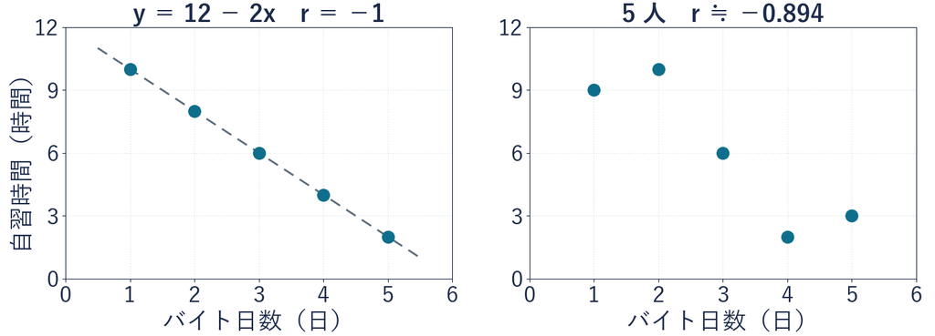

- **決まり**：どんなデータでも −1 から 1 に入る  
  （理由は教科書 第11章 11.10 の付録）
- **−1 と 1**：全部の点が直線に乗る。5 人の −0.894 は −1 に近い
- **計算できないとき**：全員が同じ値の列（標準偏差が 0）
- **Excel では**：`CORREL(x の範囲, y の範囲)` で r が 1 回で出る

## デモ：相関の実験室

数の話

共分散 ＝ 偏差の積の平均（人数 n で割る）  
相関係数 r ＝ 共分散 ÷（x の標準偏差 × y の標準偏差）

- **何を見るか**：点を動かすと、  
  平均の十字・区画の色・積・共分散・r が一緒に動く
- **図の意味**：左は散布図と平均の十字と積の長方形、右は共分散と r
- **操作**：点のドラッグ・つまみ・タブ・F のボタン・元に戻す

ミッション E さんを動かして、r がどこまで −1 に近づくか見る

※ 次のスライドへ進むときは、デモの枠の外を一度クリックしてから ← → キーを押す

[interactive chart not shown]

## 5 人の相関係数の 2 通り

1. **標準偏差**：「5人」の  
   I3 に `=STDEV.P(B2:B6)`  
   I4 に `=STDEV.P(C2:C6)`
2. **式で**：I5 に `=I2/(I3*I4)`  
   → −0.894
3. **関数で**：I6 に  
   `=CORREL(B2:B6,C2:C6)`

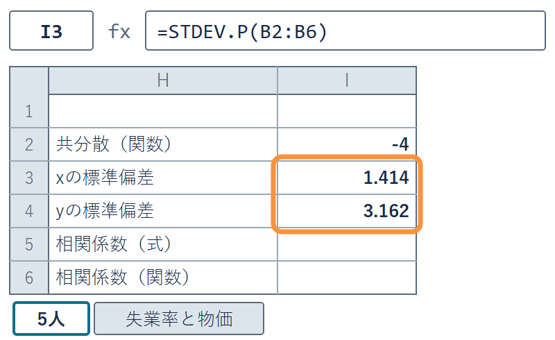

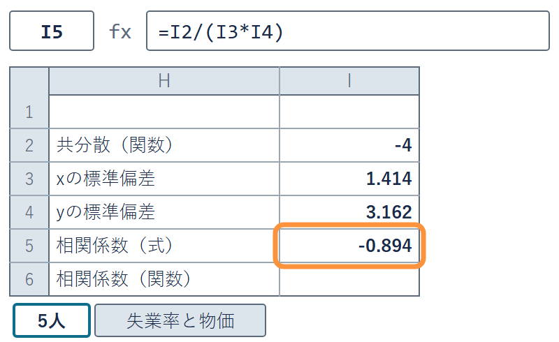

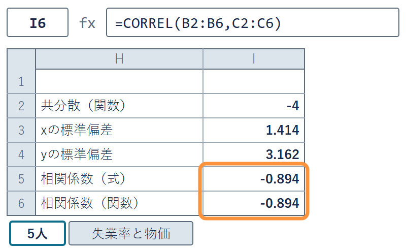

✋ 動画を止めて ①〜③ を進め、I5 と I6 が同じなら再生に戻る

## 36 年の相関係数

1. **標準偏差**：「失業率と物価」の  
   I3 に `=STDEV.P(B2:B37)`  
   I4 に `=STDEV.P(C2:C37)`
2. **式で**：I5 に `=I2/(I3*I4)`  
   → −0.737
3. **関数で**：I6 に  
   `=CORREL(B2:B37,C2:C37)`

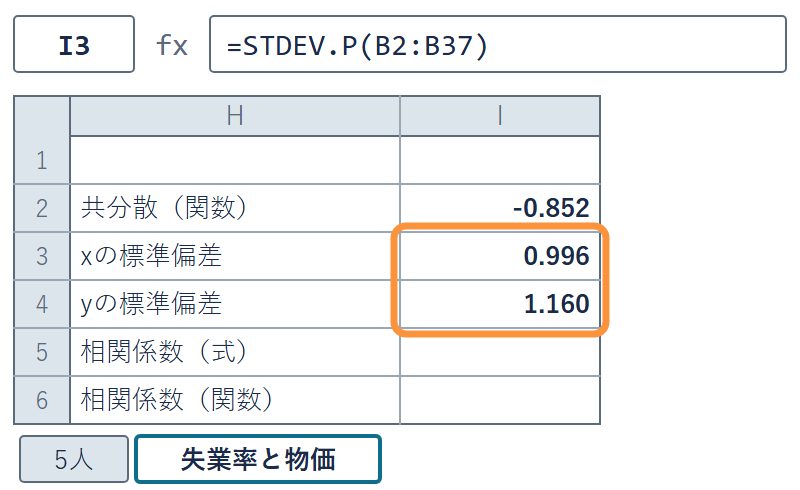

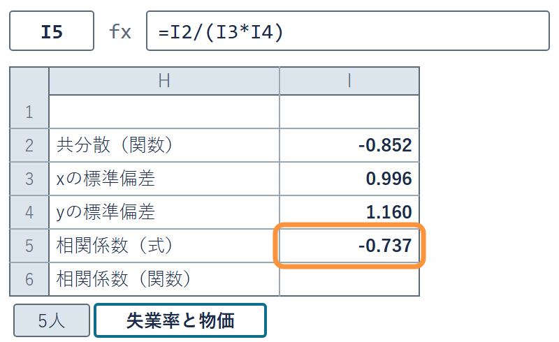

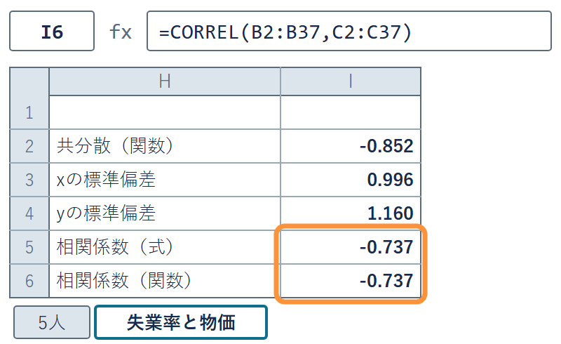

失業率 0.996・物価上昇率 1.160 で −0.852 ÷（0.996 × 1.160）≒ −0.737

✋ 動画を止めて ①〜③ を進め、−0.737 が出たら再生に戻る

## 相関係数の目安

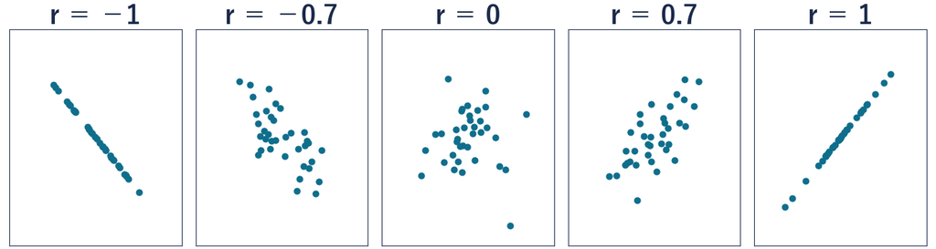

- **大きさ**：マイナスの符号を外した数（−0.737 なら 0.737）
- **目安**：0.7 以上で強い・0.4〜0.7 で中くらい  
  0.2〜0.4 で弱い・0.2 未満でほとんど無い（分野で変わる）

## 5 人と 36 年の相関係数

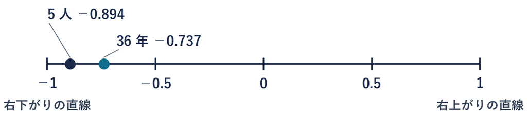

単位が無いので、5 人と 36 年を同じ物差しで並べられる  
5 人のほうが直線に近い。36 年も強い右下がり（大きさ 0.737）

## 演習 9-3 分で数えた相関係数

演習 9-3

自習時間を分に直しても、相関係数は同じか

1. **予想**：分にすると、共分散と相関係数はそれぞれ何倍になるか、  
   頭の中で決める（提出しない）
2. **分の列**：G2 に `=C2*$I$8`（I8 に 60 を印刷済み）→ 右下の四角を G6 まで引く
3. **関数**：I9 に B2:B6 と G2:G6 の CORREL、I10 に同じ範囲の COVARIANCE.P
4. **答え**：I9 の値を L2 に、I10 の値を L3 に、小数第 3 位までの数字で打つ

**サンプルデータ**：シート「5人」の A1:C6